# KAMEN4_MIRANDA_BOON_MODULE_4

## Module 4: KAMEN4_MIRANDA_BOON_MODULE_4.IPYNB

## Team Members:

*Hazel Miranda and Spencer Boon*

## Disease Background:

Using your assigned disease, fill in the following bullet points.

- Prevalence & incidence
  - *A review of Nigerian measles data found that in one secondary health-centre study in southern Nigeria, measles accounted for 3.1% of all paediatric admissions over a 5-year period.*
  - *Another study tracking incidence data across Nigeria noted that in 2021 the country had the largest number of measles cases of any country, over 10,000 reported cases.*
  - *The “Trends of the second measles vaccine (MCV2)” paper noted that Nigeria has “one of the highest measles burdens and lowest vaccination coverage in the world.”*
  - *While exact national incidence per year for your dataset period (2007-2021) might require digging into surveillance datasets, the literature clearly shows that measles remains endemic in Nigeria with frequent outbreaks, and that incidence has been persistently high.*

  Sources: https://pmc.ncbi.nlm.nih.gov/articles/PMC6445333/ https://www.frontiersin.org/journals/public-health/articles/10.3389/fpubh.2024.1392996/
- Economic burden
  - *A paper on catastrophic health expenditures (CHE) for measles in Nigeria found that contracting measles puts households at risk of CHE (out-of-pocket medical costs exceeding a threshold of income/consumption).*
  - *It shows that poorer households and those in certain regions (e.g., north vs south) have substantially higher CHE risk when measles occurs.*
  - *Another costing study of measles campaigns in Nigeria (2019 data) showed that an integrated measles vaccination campaign saved up to USD $420,000 compared to stand-alone campaigns in five states; savings of over $200 per 1,000 children were documented.*
  - *Another study in southeast Nigeria found the cost per child immunized (routine immunization) for measles was US $1.41 (total cost), and US $1.01 (operational cost) per child.*
  - *Measles exerts an economic burden via both direct medical costs (treatment, hospitalisation) and vaccination-programme costs, and that poor vaccination coverage actually translates into larger outbreaks and higher costs. Use the Nigeria-specific figures above.*

  Sources: https://pmc.ncbi.nlm.nih.gov/articles/PMC9302492/ https://healtheconomicsreview.biomedcentral.com/articles/10.1186/s13561-023-00441-y
- Risk factors (genetic, lifestyle) & Societal determinants
  - *Vaccination status is the major determinant: the “Trends of MCV2” study found very low coverage of the second dose of measles vaccine in Nigeria (≈20% when introduced, rising to only ~38-46% in some northern zones) thus leaving large susceptible populations.*
  - *Broader societal determinants: the “Population-Level Risk Factors” study identified many indicators that correlate with measles case fatality and likely with incidence: under-five mortality rate, vaccination coverage, travel time to health facility, stunting/malnutrition prevalence, conflict/displacement.*
  - *A Nigeria-specific review (2024) emphasized how conflict-affected zones, displaced populations, rapid urbanization, and poor immunization access all drive recurrent outbreaks.*
  - *Genetic risk factors: There is little evidence in Nigeria-specific literature for a strong genetic predisposition to measles; the risk is driven far more by vaccination status, immunity status, and exposure.*
  - *Lifestyle factors: Malnutrition (vitamin A deficiency, under‐nutrition), poor access to health services, high population density/household crowding are important.*
  - *The key risk factors are low vaccination coverage, poverty/inequity in access, malnutrition/immune compromised children, geographic/socio-political context (conflict/displacement). Genetic risk is minimal in the literature in this setting.*

  Sources: https://www.frontiersin.org/journals/public-health/articles/10.3389/fpubh.2024.1392996/full https://www.mdpi.com/2076-393X/11/8/1389 https://aeji.journals.ekb.eg/article_392829.html
- Symptoms
  - *According to the standard clinical description (CDC Pink Book) measles begins with high fever, cough, coryza (runny nose), conjunctivitis; 2‐3 days later Koplik’s spots (tiny white lesions inside mouth) appear; then a characteristic red maculopapular (flat and raised) rash develops, usually starting on the face and spreading downward.*
  - *In Nigeria, hospital studies report typical presentations in children: rash, fever, complications like pneumonia, otitis media, encephalitis.*
  - *Key complications: pneumonia (most common cause of death in measles in low‐income settings), diarrhoea, ear infections, blindness/corneal scarring, encephalitis, subacute sclerosing panencephalitis (SSPE) years later.*

  Sources: https://www.cdc.gov/pinkbook/hcp/table-of-contents/chapter-13-measles.html https://journals.plos.org/plosmedicine/article?id=10.1371%2Fjournal.pmed.0040016 https://pmc.ncbi.nlm.nih.gov/articles/PMC6445333/
- Diagnosis
  - *The CDC Pink Book chapter outlines diagnosis: clinical presentation (fever + cough + coryza + conjunctivitis + rash) plus laboratory confirmation via measles IgM antibodies in serum or measles virus RNA via PCR from throat/urine.*
  - *In Nigeria case‐based surveillance systems treat reported suspected measles cases, then confirm via lab/epidemiological linkage. For example the review “Control of Measles in Nigeria” describes Nigeria’s surveillance system established in 2006.*
  - *Diagnosis in Nigeria includes suspected case definition, lab confirmation (IgM/RT-PCR), and epidemiological linkage. Also understand there are limitations in resource-limited settings such as incomplete lab access, underreporting.*

  Sources: https://www.cdc.gov/pinkbook/hcp/table-of-contents/chapter-13-measles.html https://www.journaljammr.com/index.php/JAMMR/article/view/1411
- Biological mechanisms (anatomy, organ physiology, cell & molecular physiology)
  - *Pathogen: the Measles virus (MeV) is a single-stranded, negative‐sense, enveloped RNA virus in the genus Morbillivirus (family Paramyxoviridae).*
  - *Entry & spread: MeV enters via the respiratory tract, infects alveolar macrophages or dendritic cells via the SLAM (CD150) receptor on immune cells. Then it spreads to lymphoid tissues causing viremia. Later it infects epithelial cells via the nectin-4 receptor, leading to rash and virus shedding via the respiratory route.*
  - *Immune effects: MeV causes immune suppression and “immune amnesia” by depleting memory B and T-cells, meaning after measles infection the host’s immune memory to other pathogens is reduced for months/years.*
  - *Organ systems: The virus impacts the respiratory system (cough, pneumonia), skin (rash from infected epithelial cells with immune response), immune system (persistent immunosuppression), and sometimes nervous system (encephalitis, SSPE).*
  - *Cell/molecular level: MeV’s hemagglutinin (H) and fusion (F) glycoproteins mediate attachment and fusion; H binds receptors (SLAM/CD150, nectin-4) triggering fusion of viral envelope and host cell membrane via F protein.*
  - *Steps:*
  - *(1) inhalation*
  - *(2) infection of immune cells*
  - *(3) viremia*
  - *(4) infection of epithelial/skin cells*
  - *(5) rash and viral shedding + immune suppression*
  - *(6) secondary infections due to immunosuppression*
  - *Note: High-R₀ arises partly because of this efficient spread and high susceptibility of children in Nigeria.*

  Sources: https://www.thelancet.com/journals/lancet/article/PIIS0140-6736%2821%2902004-3/fulltext https://www.mdpi.com/1999-4915/14/12/2641 https://www.nature.com/articles/s41467-018-07515-0

## Dataset:

### How the data was collected

*(Describe the data set you will analyze. Cite the source(s) of the data. Describe how the data was collected -- What techniques were used? What units are the data measured in? Etc.)*

- Our data set is from Adebayo, A. (2022). Nigeria Measles Outbreak Dataset (2007-2021) [Data set]. Kaggle. https://www.kaggle.com/datasets/adegboyegaadebayo/nigeria-measles-outbreak-dataset2007-2021
  - The measles epidemiological data used for the data set was extracted from the Nigeria Centre Disease Control situation report and the national disease outbreak dashboard (https://ncdc.gov.ng/data) using the application webplotdigitizer (https://apps.automeris.io/wpd/)
    - These are official national surveillance summaries reporting:
      - Number of suspected and confirmed measles cases
      - Geographic distribution
      - Time trends (weekly, monthly, or yearly)
      - Outbreak counts
      - Case totals by state
      - Time-series visualizations
      - Laboratory confirmations in some years

### Techniques used to extract the dataset

The dataset creator did not download raw spreadsheets from NCDC (because NCDC often publishes graphs instead of downloadable files). Instead, they used WebPlotDigitizer (A digital extraction tool that allows a user to upload a plot or graph and convert the plotted points into numerical data)

- This means: The researcher took graphs (case counts over time, outbreak charts, etc.) from NCDC reports.
  - Uploaded them into WebPlotDigitizer.
  - Extracted the exact numerical values (e.g., monthly or yearly case counts).
  - Compiled these into a CSV file.
  - This is a recognized and common technique used in research when data are only available as plotted figures, not tables.

### Data set qualities

- The data is Weekly collected (not daily) from 2020-08-03 to 2022-01-03
- Accoss multiple online sources the concensous is that measles infectious period is about 10-14 days. For our project we will use the median of 12 and round it up to 2 weeks.
- The data is not cumulative and compares new cases

```python
## LOAD YOUR DATASET HERE.
import pandas as pd
import matplotlib.pyplot as plt
from main_functions import convert_cumulative_to_SIR
# 1. Read your weekly measles data
df = pd.read_csv("measles_nigeria_data_2020-2021_new_cases.csv")
df["date"] = pd.to_datetime(df["date"])
# The CSV has weekly *new* confirmed cases.
# Build a cumulative column for the helper function:
df["cumulative_cases"] = df["confirmed_cases"].cumsum()

# 2. Convert cumulative cases → S, I, R using a WEEK-based infectious period
population_nigeria = 206_000_000  # approx 2020–2021
infectious_period_weeks = 2       # 12 days ≈ 1.7 weeks → ~2 weekly time steps
sir_df = convert_cumulative_to_SIR(
    df,
    date_col="date",
    cumulative_col="cumulative_cases",
    population=population_nigeria,
    infectious_period=infectious_period_weeks)
print(sir_df.head())
```

```
        date  confirmed_cases  cumulative_cases  new_cases  I_est  R_est  \
0 2020-08-03             25.0              25.0       25.0   25.0    0.0
1 2020-08-10             29.0              54.0       29.0   54.0    0.0
2 2020-08-17             27.0              81.0       27.0   56.0   25.0
3 2020-08-24             20.0             101.0       20.0   47.0   54.0
4 2020-08-31             17.0             118.0       17.0   37.0   81.0

         S_est
0  205999975.0
1  205999946.0
2  205999919.0
3  205999899.0
4  205999882.0
```

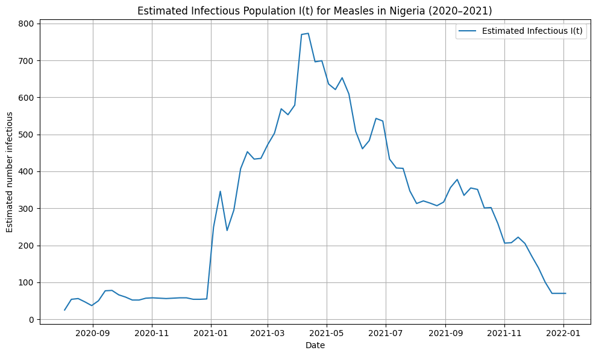

```python
# Plot I(t) alone
plt.figure(figsize=(10, 6))
plt.plot(sir_df["date"], sir_df["I_est"], label="Estimated Infectious I(t)")
plt.xlabel("Date")
plt.ylabel("Estimated number infectious")
plt.title("Estimated Infectious Population I(t) for Measles in Nigeria (2020–2021)")
plt.grid(True)
plt.legend()
plt.tight_layout()
plt.show()
```

## Data Analyis:

### Methods

To analyze measles transmission in Nigeria, we started with weekly confirmed case counts from 2020–2021. We first constructed a cumulative case curve and used it to estimate SIR compartments by assuming an infectious period of two weeks. Specifically, we computed weekly new cases, estimated the infectious population I(t) as a 2-week rolling sum of new cases, approximated the recovered population R(t) as the cumulative cases shifted forward by two weeks, and then defined the susceptible population S(t) as 𝑆(𝑡)=𝑁−𝐼(𝑡)−𝑅(𝑡) where N is the approximate total population of Nigeria.

We then modeled disease dynamics using the standard SIR system of ODEs and implemented two numerical solvers. First, we used Euler’s method to simulate S(t), I(t), and R(t) for given transmission (β) and recovery (γ) rates, and we quantified model–data mismatch using the sum of squared errors (SSE) between modeled and data-based I(t). We fit β and γ in two ways: (1) using scipy.optimize.minimize on the full time series, and (2) using a grid search that minimized SSE only on the first half of the data, then computed SSE on the second half as an out-of-sample prediction error. Finally, to reduce numerical error, we replaced Euler’s method with scipy.integrate.solve_ivp using the RK45 scheme, repeated the first-half fitting and second-half evaluation, and compared the resulting SSE values from Euler and RK45 to assess the impact of the numerical method on model accuracy.

### Analysis

*(Describe how you analyzed the data. This is where you should intersperse your Python code so that anyone reading this can run your code to perform the analysis that you did, generate your figures, etc.)*

##### 2. Predict "the future" with your fit SIR model:

```
I_true min/max: 25.0 773.0
I_model min/max: 25.0 455.40494403116116
```

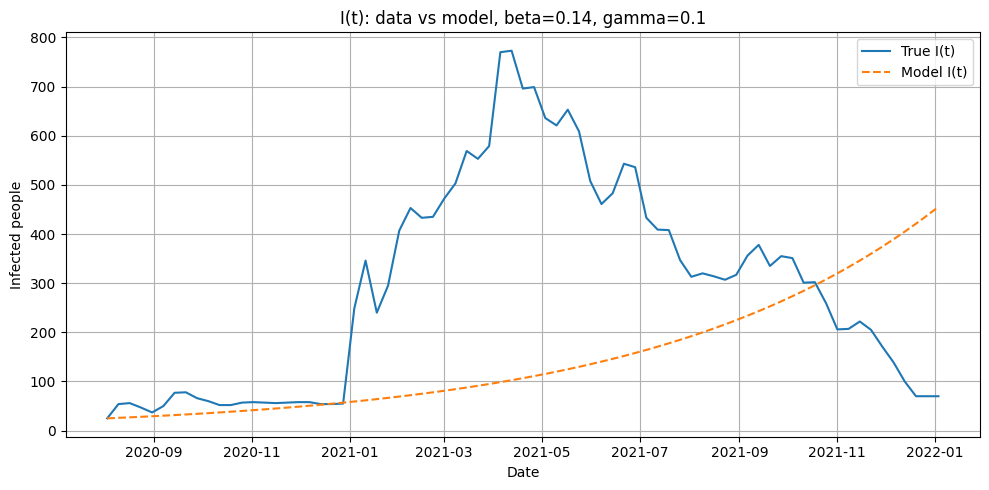

```
SSE for I(t): 6001542.017750413
```

```python
## Plot of Euler, I(t) true and I(t) model with gamma and beta guess

import pandas as pd
import numpy as np
from main_functions import convert_cumulative_to_SIR

def euler_sir(beta, gamma, S0, I0, R0, t, N):
    """
    Solve the SIR model using Euler's method.
    """

    # Preallocate arrays for S(t), I(t), R(t)
    S = np.empty(len(t), float)
    I = np.empty(len(t), float)
    R = np.empty(len(t), float)

    # Set initial conditions from data
    S[0], I[0], R[0] = S0, I0, R0

    # Loop through all time steps and apply Euler updates
    for n in range(len(t) - 1):
        dt = t[n + 1] - t[n]   # time step size

        # SIR differential equations
        dS = -beta * S[n] * I[n] / N
        dI = beta * S[n] * I[n] / N - gamma * I[n]
        dR = gamma * I[n]

        # Euler update rule: next value = current + derivative * dt
        S[n + 1] = S[n] + dS * dt
        I[n + 1] = I[n] + dI * dt
        R[n + 1] = R[n] + dR * dt

    return S, I, R


# Convert cumulative case data → S, I, R estimated from real data
sir_df = convert_cumulative_to_SIR(
    df,
    date_col="date",
    cumulative_col="cumulative_cases",
    population=population_nigeria,
    infectious_period=infectious_period_weeks)

# Create time array (one step per row in dataframe)
t = np.arange(len(sir_df), dtype=float)

# Total population
N = population_nigeria

# Initial S, I, R taken from the first row of estimated SIR dataset
S0 = sir_df["S_est"].iloc[0]
I0 = sir_df["I_est"].iloc[0]
R0 = sir_df["R_est"].iloc[0]

# True I(t) from data
I_true = sir_df["I_est"].values

# Parameter guesses for Euler simulation
beta_guess = 0.14
gamma_guess = 0.1

# Run Euler SIR model using guessed beta and gamma
S_model, I_model, R_model = euler_sir(
    beta=beta_guess,
    gamma=gamma_guess,
    S0=S0,
    I0=I0,
    R0=R0,
    t=t,
    N=N)
# Quick diagnostics of model performance
print("I_true min/max:", I_true.min(), I_true.max())
print("I_model min/max:", I_model.min(), I_model.max())

# -------- Plot: TRUE vs MODEL I(t) --------
plt.figure(figsize=(10, 5))
plt.plot(sir_df["date"], I_true, label="True I(t)")                     # data-based estimated I(t)
plt.plot(sir_df["date"], I_model, label="Model I(t)", linestyle="--")   # Euler-simulated I(t)
plt.xlabel("Date")
plt.ylabel("Infected people")
plt.title(f"I(t): data vs model, beta={beta_guess}, gamma={gamma_guess}")
plt.legend()
plt.grid(True)
plt.tight_layout()
plt.show()

# Compute SSE between model I(t) and true I(t)
sse_I = np.sum((I_model - I_true) ** 2)
print("SSE for I(t):", sse_I)
```

```
Optimal beta: 0.4657494404878756
Optimal gamma: 0.4261809105915359
Optimal SSE: 5999184.742740708
```

[figure not shown]

```python
## Optimized graph of beta and gamma with best values and new SSE

from scipy.optimize import minimize

# True I(t) from data and setup for SIR model
I_true = sir_df["I_est"].values
t = np.arange(len(sir_df), dtype=float)
N = population_nigeria

# Initial conditions from first row of SIR estimates
S0 = sir_df["S_est"].iloc[0]
I0 = sir_df["I_est"].iloc[0]
R0 = sir_df["R_est"].iloc[0]

def sse_objective(params):
    """
    Objective function for optimization.
    params[0] = beta, params[1] = gamma.
    Returns SSE between model I(t) and data I_true.
    """
    beta, gamma = params

    # Penalize non-physical negative parameters
    if beta <= 0 or gamma <= 0:
        return 1e30  # huge penalty

    # Simulate SIR model with current beta, gamma
    S_model, I_model, R_model = euler_sir(
        beta=beta,
        gamma=gamma,
        S0=S0,
        I0=I0,
        R0=R0,
        t=t,
        N=N
    )

    # Sum of squared errors between model and data
    return np.sum((I_model - I_true) ** 2)


# Initial guess for (beta, gamma)
initial_guess = np.array([0.2, 0.5])

# Bounds to keep beta, gamma in reasonable ranges
bounds = [
    (1e-6, 2.0),  # beta between ~0 and 2 per week
    (1e-6, 2.0)   # gamma between ~0 and 2 per week
    ]

# Run numerical optimization to minimize SSE
result = minimize(
    sse_objective,
    x0=initial_guess,
    bounds=bounds,
    method="L-BFGS-B")

# Extract optimal parameters
beta_opt, gamma_opt = result.x

print("Optimal beta:", beta_opt)
print("Optimal gamma:", gamma_opt)
print("Optimal SSE:", result.fun)

# Recompute SIR trajectories with optimal parameters
S_opt, I_opt, R_opt = euler_sir(
    beta=beta_opt,
    gamma=gamma_opt,
    S0=S0,
    I0=I0,
    R0=R0,
    t=t,
    N=N)

# Plot data vs optimized model
plt.figure(figsize=(10, 5))
plt.plot(sir_df["date"], I_true, label="True I(t)")  # data-based I(t)
plt.plot(
    sir_df["date"],
    I_opt,
    "--",
    label=f"Model I(t), β={beta_opt:.3f}, γ={gamma_opt:.3f}")
plt.xlabel("Date")
plt.ylabel("Infected people")
plt.title("I(t): data vs optimized SIR model (SciPy minimize)")
plt.legend()
plt.grid(True)
plt.tight_layout()
plt.show()
```

```
Best beta (fit on first half): 0.15142857142857144
Best gamma (fit on first half): 0.05
Best SSE on FIRST HALF: 124374.48717843318
SSE on SECOND HALF (prediction error for Euler model): 5618617930.049551
```

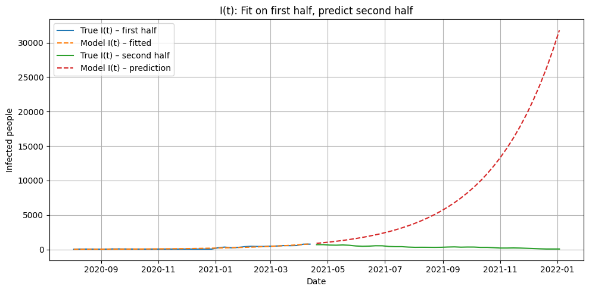

```python
## Fitting with first half of data, and calculating SSE on second half of data

# Full I(t) and date arrays from SIR estimates
I_true_all = sir_df["I_est"].values
dates_all = sir_df["date"].values
n = len(sir_df)

# Time array for full dataset (assume weekly spacing)
t_all = np.arange(n, dtype=float)

# Split index between first and second half of time series
mid = n // 2  # integer division

# First-half data (used for fitting parameters)
I_true_fit = I_true_all[:mid]
t_fit = t_all[:mid]

# Second-half data (used only for evaluating prediction error)
I_true_second = I_true_all[mid:]
t_second = t_all[mid:]

N = population_nigeria

# Initial conditions from the first row of SIR estimates
S0 = sir_df["S_est"].iloc[0]
I0 = sir_df["I_est"].iloc[0]
R0 = sir_df["R_est"].iloc[0]

# ---------- SSE function that uses ONLY FIRST HALF ----------
def sir_sse_first_half(beta, gamma):
    """
    Compute SSE between model and data for the FIRST HALF of the time series.
    """
    # Run SIR model over full time span
    S_model, I_model, R_model = euler_sir(
        beta=beta,
        gamma=gamma,
        S0=S0,
        I0=I0,
        R0=R0,
        t=t_all,
        N=N
    )
    # Restrict SSE calculation to first-half data points
    return np.sum((I_model[:mid] - I_true_fit) ** 2)

# ---------- GRID SEARCH on beta, gamma using FIRST HALF ----------
beta_values = np.linspace(0.01, 1.0, 50)   # search range for beta
gamma_values = np.linspace(0.05, 1.0, 50)  # search range for gamma

best_sse = np.inf
best_beta = None
best_gamma = None

# Brute-force search over grid of (beta, gamma) pairs
for beta in beta_values:
    for gamma in gamma_values:
        sse = sir_sse_first_half(beta, gamma)
        if sse < best_sse:
            best_sse = sse
            best_beta = beta
            best_gamma = gamma

print("Best beta (fit on first half):", best_beta)
print("Best gamma (fit on first half):", best_gamma)
print("Best SSE on FIRST HALF:", best_sse)

# ---------- RUN MODEL WITH BEST PARAMETERS ON FULL TIME RANGE ----------
S_best, I_best, R_best = euler_sir(
    beta=best_beta,
    gamma=best_gamma,
    S0=S0,
    I0=I0,
    R0=R0,
    t=t_all,
    N=N)

# ---------- COMPUTE ERROR ON SECOND HALF ----------
# Model-predicted I(t) over second half
I_model_second = I_best[mid:]
sse_second_half = np.sum((I_model_second - I_true_second) ** 2)

print("SSE on SECOND HALF (prediction error for Euler model):", sse_second_half)

# ---------- PLOT: FIT ON FIRST HALF, PREDICT SECOND HALF ----------
plt.figure(figsize=(10, 5))

# First half: where parameters were fit
plt.plot(dates_all[:mid], I_true_fit, label="True I(t) – first half")
plt.plot(dates_all[:mid], I_best[:mid], "--", label="Model I(t) – fitted")

# Second half: model prediction vs data
plt.plot(dates_all[mid:], I_true_second, label="True I(t) – second half")
plt.plot(dates_all[mid:], I_model_second, "--", label="Model I(t) – prediction")

plt.xlabel("Date")
plt.ylabel("Infected people")
plt.title("I(t): Fit on first half, predict second half")
plt.legend()
plt.grid(True)
plt.tight_layout()
plt.show()
```

```python
## RK45 (solve_ivp) SIR fitting and comparison to Euler

from scipy.integrate import solve_ivp

def sir_ode(t, y, beta, gamma, N):
    """
    Right-hand side of the SIR ODE system for solve_ivp.
    y = [S, I, R]
    """
    S, I, R = y
    dSdt = -beta * S * I / N
    dIdt = beta * S * I / N - gamma * I
    dRdt = gamma * I
    return [dSdt, dIdt, dRdt]

def rk45_sir(beta, gamma, S0, I0, R0, t_eval, N):
    """
    Integrate the SIR model using solve_ivp with RK45.
    - t_eval: array of time points where solution is returned (e.g., t_all = np.arange(n))
    Returns S, I, R arrays aligned with t_eval.
    """
    sol = solve_ivp(
        fun=lambda t, y: sir_ode(t, y, beta, gamma, N),
        t_span=(t_eval[0], t_eval[-1]),
        y0=[S0, I0, R0],
        t_eval=t_eval,
        method="RK45"
    )

    # If solver fails, raise so we can penalize in SSE function
    if not sol.success:
        raise RuntimeError("solve_ivp failed: " + sol.message)

    # sol.y has shape (3, len(t_eval)): rows = S, I, R
    S, I, R = sol.y
    return S, I, R


# ---------- DATA & TIME SETUP ----------
I_true_all = sir_df["I_est"].values
dates_all = sir_df["date"].values
n = len(sir_df)

# Time array (assume weekly spacing)
t_all = np.arange(n, dtype=float)

# Split into first and second halves
mid = n // 2
I_true_fit = I_true_all[:mid]      # first half (for fitting)
t_fit = t_all[:mid]
I_true_second = I_true_all[mid:]   # second half (for prediction error)
t_second = t_all[mid:]

# Population and initial conditions
N = population_nigeria
S0 = sir_df["S_est"].iloc[0]
I0 = sir_df["I_est"].iloc[0]
R0 = sir_df["R_est"].iloc[0]

import numpy as np

def sir_sse_first_half_rk45(beta, gamma):
    """
    SSE between RK45-based SIR model and data for the FIRST HALF of the time series.
    """
    # Enforce positivity; negative parameters are non-physical
    if beta <= 0 or gamma <= 0:
        return 1e30

    try:
        # Integrate over the full time range
        S_model, I_model, R_model = rk45_sir(
            beta=beta,
            gamma=gamma,
            S0=S0,
            I0=I0,
            R0=R0,
            t_eval=t_all,
            N=N
        )
    except RuntimeError:
        # If the ODE solver fails, treat this parameter pair as very bad
        return 1e30

    # SSE only on first-half data points
    return np.sum((I_model[:mid] - I_true_fit) ** 2)


# ---------- GRID SEARCH (RK45) ON FIRST HALF ----------
beta_values = np.linspace(0.01, 1.0, 50)   # search grid for beta
gamma_values = np.linspace(0.05, 1.0, 50)  # search grid for gamma

best_sse_rk45 = np.inf
best_beta_rk45 = None
best_gamma_rk45 = None

# Brute-force search over (beta, gamma) pairs
for beta in beta_values:
    for gamma in gamma_values:
        sse = sir_sse_first_half_rk45(beta, gamma)
        if sse < best_sse_rk45:
            best_sse_rk45 = sse
            best_beta_rk45 = beta
            best_gamma_rk45 = gamma

print("RK45 best beta (fit on first half):", best_beta_rk45)
print("RK45 best gamma (fit on first half):", best_gamma_rk45)
print("RK45 best SSE on FIRST HALF:", best_sse_rk45)


# ---------- RUN RK45 MODEL WITH BEST PARAMETERS ON FULL TIME RANGE ----------
S_best_rk45, I_best_rk45, R_best_rk45 = rk45_sir(
    beta=best_beta_rk45,
    gamma=best_gamma_rk45,
    S0=S0,
    I0=I0,
    R0=R0,
    t_eval=t_all,
    N=N
)

# ---------- SECOND-HALF SSE (PREDICTION ERROR) ----------
I_model_second_rk45 = I_best_rk45[mid:]
sse_second_half_rk45 = np.sum((I_model_second_rk45 - I_true_second) ** 2)

# sse_second_half is the Euler-based second-half SSE computed earlier
print("Euler SSE on second half:", sse_second_half)
print("RK45 SSE on second half:", sse_second_half_rk45)
```

```
RK45 best beta (fit on first half): 0.9797959183673469
RK45 best gamma (fit on first half): 0.8836734693877552
RK45 best SSE on FIRST HALF: 124408.63390074746
Euler SSE on second half: 5618617930.049551
RK45 SSE on second half: 5133231354.87359
```

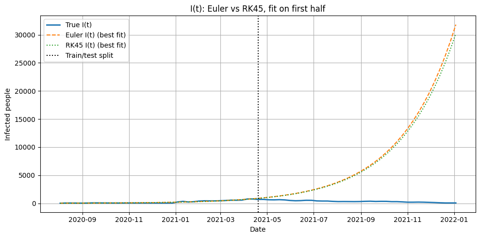

```python
## Comparison of Euler vs RK45 on our data

plt.figure(figsize=(10, 5))

# True infections over time from data
plt.plot(dates_all, I_true_all, label="True I(t)", linewidth=2)

# Euler model prediction (best-fit parameters from grid search)
plt.plot(dates_all, I_best, "--", label="Euler I(t) (best fit)")

# RK45 model prediction (best-fit parameters from RK45 grid search)
plt.plot(dates_all, I_best_rk45, ":", label="RK45 I(t) (best fit)")

# Vertical line indicating where we split first/second half (train/test)
plt.axvline(dates_all[mid], color="k", linestyle=":", label="Train/test split")

plt.xlabel("Date")
plt.ylabel("Infected people")
plt.title("I(t): Euler vs RK45, fit on first half")
plt.legend()
plt.grid(True)
plt.tight_layout()
plt.show()
```

## NOTES FROM YOUR TEAM:

- Just plotted I vs t because this demonstrated our data better. S(t)'s values where too high and R(t) grew too quick for a clean visual S,I,R plot.
- We worked together to divide the work evenly.
- We collaberated by sharing ideas and progress in Github.

## QUESTIONS FOR YOUR TA:

We have no question at the moment.